# Text analysis on iPod Reviews

## Sentiment Analysis

To run sentiment analysis, we need a lexicon. In Quanteda, lexicons are also referred to as dictionaries. An easy lexicon to use is the LSD lexicon, which just scores words as negative or positive. It is available simply by calling “data_dictionary_LSD2015”:

```r
data_dictionary_LSD2015
```

```
Dictionary object with 4 key entries.
- [negative]:
  - a lie, abandon*, abas*, abattoir*, abdicat*, aberra*, abhor*, abject*, abnormal*, abolish*, abominab*, abominat*, abrasiv*, absent*, abstrus*, absurd*, abus*, accident*, accost*, accursed* [ ... and 2,838 more ]
- [positive]:
  - ability*, abound*, absolv*, absorbent*, absorption*, abundanc*, abundant*, acced*, accentuat*, accept*, accessib*, acclaim*, acclamation*, accolad*, accommodat*, accomplish*, accord, accordan*, accorded*, accords [ ... and 1,689 more ]
- [neg_positive]:
  - best not, better not, no damag*, no no, not ability*, not able, not abound*, not absolv*, not absorbent*, not absorption*, not abundanc*, not abundant*, not acced*, not accentuat*, not accept*, not accessib*, not acclaim*, not acclamation*, not accolad*, not accommodat* [ ... and 1,701 more ]
- [neg_negative]:
  - not a lie, not abandon*, not abas*, not abattoir*, not abdicat*, not aberra*, not abhor*, not abject*, not abnormal*, not abolish*, not abominab*, not abominat*, not abrasiv*, not absent*, not abstrus*, not absurd*, not abus*, not accident*, not accost*, not accursed* [ ... and 2,840 more ]
```

To use this for sentiment analysis, we again use the dfm command:

```r
senti = dfm_lookup(trimmed_dfm, dictionary = data_dictionary_LSD2015)
senti
```

```
Document-feature matrix of: 200 documents, 4 features (58.88% sparse) and 0 docvars.
       features
docs    negative positive neg_positive neg_negative
  text1        5       13            0            0
  text2        0        6            0            0
  text3        3        8            0            0
  text4        2        3            0            0
  text5        0        0            0            0
  text6        0        0            0            0
[ reached max_ndoc ... 194 more documents ]
```

Let’s compute the fraction of positive words:

```r
frac_pos = senti[,2]/(senti[,1]+senti[,2])
```

Does the fraction of positive words correlate with the star rating?

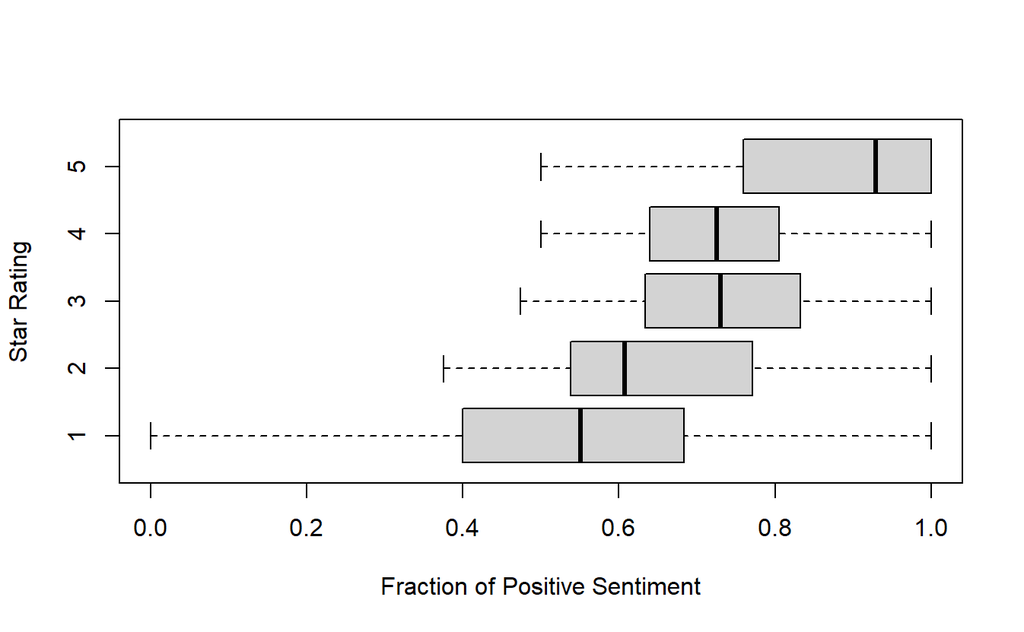

```r
boxplot(as.matrix(frac_pos) ~ reviews$Rating[1:200], horizontal = TRUE, xlab = "Fraction of Positive Sentiment", ylab = "Star Rating")
```

## Topic Modelling

First, convert the DFM to the format needed for LDA from the topicmodels package:

```r
dtm_reviews = convert(trimmed_dfm, to="topicmodels")
```

Pick the number of topics, and run LDA. There are two methods you can use, which control which algorithm is learn the model parameters: the default is method=“VEM”, which is faster, but the other option, method=“Gibbs” often gives better results

```r
n_topics = 6
rev_lda = LDA(dtm_reviews, k=n_topics, method="Gibbs")
```

To see the results, we have to either call “terms” or “posterior”

- “terms” shows us the top k words that are associated with each topic:

```r
terms(rev_lda, k=5)
```

```
     Topic 1  Topic 2 Topic 3 Topic 4  Topic 5  Topic 6
[1,] "can"    "apple" "ipad"  "ipad"   "use"    "laptop"
[2,] "video"  "one"   "app"   "can"    "screen" "thing"
[3,] "archos" "great" "touch" "comput" "one"    "tablet"
[4,] "play"   "work"  "apple" "app"    "read"   "get"
[5,] "also"   "love"  "iphon" "store"  "lot"    "want"
```

- “posterior” shows which topics a given document (or, in this case, review) features,

```r
posterior(rev_lda)$topics[1,]
```

```
        1         2         3         4         5         6
0.1246612 0.3441734 0.1490515 0.1084011 0.1165312 0.1571816
```

Let’s see if these topics are predictive of the star rating:

```r
summary(lm(reviews$Rating[1:200] ~ 0 + posterior(rev_lda)$topics))
```

```
Call:
lm(formula = reviews$Rating[1:200] ~ 0 + posterior(rev_lda)$topics)

Residuals:
    Min      1Q  Median      3Q     Max
-3.3136 -0.9549  0.4111  1.1935  1.6847

Coefficients:
                           Estimate Std. Error t value Pr(>|t|)
posterior(rev_lda)$topics1    3.477      1.193   2.915 0.003976 **
posterior(rev_lda)$topics2    1.300      1.132   1.149 0.252081
posterior(rev_lda)$topics3    5.660      1.637   3.456 0.000673 ***
posterior(rev_lda)$topics4    4.364      1.512   2.886 0.004344 **
posterior(rev_lda)$topics5    4.261      1.632   2.610 0.009752 **
posterior(rev_lda)$topics6    3.952      1.601   2.469 0.014424 *
---
Signif. codes:  0 ‘***’ 0.001 ‘**’ 0.01 ‘*’ 0.05 ‘.’ 0.1 ‘ ’ 1

Residual standard error: 1.477 on 194 degrees of freedom
Multiple R-squared:  0.8721,    Adjusted R-squared:  0.8682
F-statistic: 220.5 on 6 and 194 DF,  p-value: < 2.2e-16
```